# predicting-votes

# O Problema

O objetivo deste exercício é construir modelos preditivos de regressão utilizando técnicas de regularização e seleção de variáveis para a predição de votos em candidatos a deputados que já exercem a função. Os dados foram divididos em dados de treinos e de teste.

# Baixando dados

```r
library(here)
library(dplyr)
library(readr)

train_data = read.csv(here::here("data/kaggle/ceap/train.csv")) %>% na.omit()
test_data = read.csv(here::here("data/kaggle/ceap/test.csv")) %>% na.omit()
```

```r
train_data %>%
  glimpse()
```

```
## Observations: 7,476
## Variables: 24
## $ ano                                   <int> 2006, 2006, 2006, 2006, ...
## $ sequencial_candidato                  <dbl> 10001, 10002, 10002, 100...
## $ nome                                  <fct> JOSÉ LUIZ NOGUEIRA DE SO...
## $ uf                                    <fct> AP, RO, AP, MS, RO, PI, ...
## $ partido                               <fct> PT, PT, PT, PRONA, PT, P...
## $ quantidade_doacoes                    <int> 6, 13, 17, 6, 48, 6, 14,...
## $ quantidade_doadores                   <int> 6, 13, 16, 6, 48, 6, 7, ...
## $ total_receita                         <dbl> 16600.00, 22826.00, 1581...
## $ media_receita                         <dbl> 2766.67, 1755.85, 9301.2...
## $ recursos_de_outros_candidatos.comites <dbl> 0.00, 6625.00, 2250.00, ...
## $ recursos_de_pessoas_fisicas           <dbl> 9000.00, 15000.00, 34150...
## $ recursos_de_pessoas_juridicas         <dbl> 6300.00, 1000.00, 62220....
## $ recursos_proprios                     <dbl> 1300.00, 201.00, 59500.0...
## $ recursos_de_partido_politico          <dbl> 0, 0, 0, 0, 0, 0, 0, 0, ...
## $ quantidade_despesas                   <int> 14, 24, 123, 8, 133, 9, ...
## $ quantidade_fornecedores               <int> 14, 23, 108, 8, 120, 9, ...
## $ total_despesa                         <dbl> 16583.60, 20325.99, 1460...
## $ media_despesa                         <dbl> 1184.54, 846.92, 1187.09...
## $ cargo                                 <fct> DEPUTADO FEDERAL, DEPUTA...
## $ sexo                                  <fct> MASCULINO, FEMININO, FEM...
## $ grau                                  <fct> ENSINO MÉDIO COMPLETO, S...
## $ estado_civil                          <fct> CASADO(A), SOLTEIRO(A), ...
## $ ocupacao                              <fct> VEREADOR, SERVIDOR PÚBLI...
## $ votos                                 <int> 8579, 2757, 17428, 1193,...
```

# Pré-processando

Iremos aplicar as seguintes transformações para ambos dados de treino e teste.

Temos algumas variáveis categóricas. Vamos transformá-las.

```r
genre_cat_to_id = function(m_genre) {
  return(ifelse(m_genre == "MASCULINO", 0, 1))
}

categoric_to_id = function(data) {
  require(dplyr)
  return(data %>%
           mutate(sexo = genre_cat_to_id(sexo),
                  grau = as.integer(as.factor(grau)),
                  estado_civil = as.integer(as.factor(estado_civil)),
                  ocupacao = as.integer(as.factor(ocupacao)),
                  partido = as.integer(as.factor(partido)),
                  uf = as.integer(as.factor(uf))))
}

train_data = train_data %>% categoric_to_id
test_data = test_data %>% categoric_to_id
```

Iremos retirar as variáveis *cargo*, pois ela é igual para todas as observações. Também iremos remover *nome e sequencial candidato*, pois são pouco relevantes.

```r
remove_irrelevante_features = function(data) {
  require(dplyr)
  return(data %>%
           select(-c(cargo, nome, sequencial_candidato)))
}

# But we will save this colum for make predictions later
ID = test_data$sequencial_candidato

train_data = train_data %>% remove_irrelevante_features
test_data = test_data %>% remove_irrelevante_features
```

Visualizando o comportamento dos dados de treino:

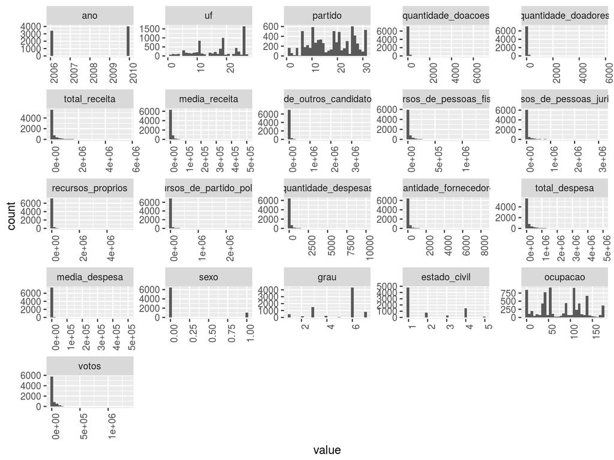

```r
plot_data_distribution = function(data) {
  require(reshape2)
  require(ggplot2)
  require(scales)

  reshaped_data =
    reshape2::melt(data)

  plot =
    ggplot(reshaped_data, aes(x = value)) +
      facet_wrap(~variable, scales = "free") +
      geom_histogram() +
      theme(axis.text.x = element_text(angle = 90, hjust = 1))

  return(plot)
}

plot_data_distribution(train_data)
```

Transformação dos dados a fim de encontrar uma distribuição normal (exceto da variávle independente, *votos*).

```r
to_log = function(x) {
  transformed = (x ** 2) %>% sqrt() %>% log()
  returned = ifelse(transformed == -Inf, x,
                    ifelse(transformed == Inf, x, transformed))
  return(returned)
}

train_data = train_data %>%
  mutate(
         quantidade_doacoes = to_log(quantidade_doacoes),
         quantidade_doadores = to_log(quantidade_doadores),
         total_receita = to_log(total_receita),
         media_receita = to_log(media_receita),
         recursos_de_outros_candidatos.comites = to_log(recursos_de_outros_candidatos.comites),
         recursos_de_pessoas_fisicas = to_log(recursos_de_pessoas_fisicas),
         recursos_de_pessoas_juridicas = to_log(recursos_de_pessoas_juridicas),
         recursos_proprios = to_log(recursos_proprios),
         recursos_de_partido_politico = to_log(recursos_de_partido_politico),
         quantidade_despesas = to_log(quantidade_despesas),
         quantidade_fornecedores = to_log(quantidade_fornecedores),
         total_despesa = to_log(total_despesa),
         media_despesa = to_log(media_despesa))

train_data = train_data %>% na.omit()
```

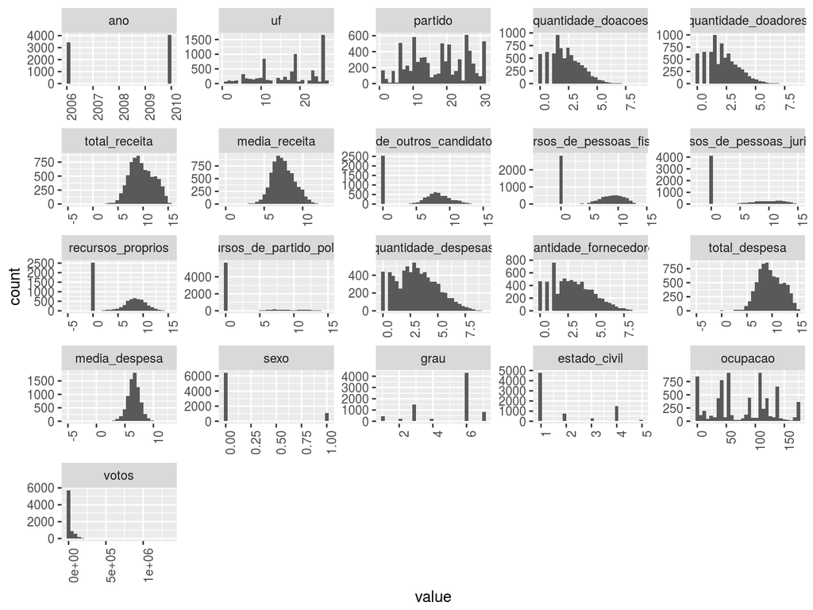

```r
plot_data_distribution(train_data)
```

# Tuanando modelos (usando validação cruzada)

Será utilizado o pacote *caret*, que implementa funções para tunar modelos usando o método Ridge, Lasso ou outros. Será utilizada uma validação cruzada 10-fold.

## Modelo de regressão Ridge

A grande vantagem do método Ridge é que através dele podemos diminuir a variância do modelo ao custo de um pequeno aumento no bias. O método ridge tende a aproximar a 0 os coeficientes das variáveis preditoras, conforme o lambda aumenta. Isso diminui a flexibilidade do modelo, diminuindo também a variância, porém aumentando o bias. A ideia por trás da regressão Ridge é encontrar um lambda que gere um trade-off satisfatório entre bias e Variância.

Treinando:

```r
library(caret)

fit_control = trainControl(method = "cv", number = 10)

# Tunando o hiperparâmetro lambda para penalização dos coeficientes
lambda_grid = expand.grid(lambda = 10^seq(10, -2, length=100))

model.ridge = train(votos ~ .,
               data = train_data,
               trControl = fit_control,
               tuneGrid = lambda_grid,
               method = "ridge",
               metric="RMSE",
               tuneLength = 100,
               importance = TRUE,
               preProcess = c("scale", "center"),
               na.action = na.omit)
```

### Avaliando treino

```r
model.ridge
```

```
## Ridge Regression
##
## 7476 samples
##   20 predictors
##
## Pre-processing: scaled (20), centered (20)
## Resampling: Cross-Validated (10 fold)
## Summary of sample sizes: 6728, 6728, 6729, 6729, 6729, 6729, ...
## Resampling results across tuning parameters:
##
##   lambda        RMSE       Rsquared   MAE
##   1.000000e-02   36096.78  0.4229922   20023.43
##   1.321941e-02   36098.15  0.4229960   20043.38
##   1.747528e-02   36100.34  0.4229968   20070.20
##   2.310130e-02   36103.78  0.4229935   20106.23
##   3.053856e-02   36109.26  0.4229838   20154.90
##   4.037017e-02   36118.08  0.4229630   20220.76
##   5.336699e-02   36132.46  0.4229234   20310.12
##   7.054802e-02   36156.15  0.4228523   20431.68
##   9.326033e-02   36195.48  0.4227309   20597.16
##   1.232847e-01   36261.13  0.4225322   20824.19
##   1.629751e-01   36370.92  0.4222208   21140.21
##   2.154435e-01   36554.38  0.4217529   21581.60
##   2.848036e-01   36859.69  0.4210804   22215.61
##   3.764936e-01   37363.67  0.4201567   23110.24
##   4.977024e-01   38184.57  0.4189471   24352.29
##   6.579332e-01   39495.25  0.4174402   26100.43
##   8.697490e-01   41530.52  0.4156571   28556.53
##   1.149757e+00   44578.91  0.4136554   31899.94
##   1.519911e+00   48950.58  0.4115225   36373.45
##   2.009233e+00   54922.45  0.4093614   42179.78
##   2.656088e+00   62674.12  0.4072725   49444.45
##   3.511192e+00   72232.70  0.4053378   58106.47
##   4.641589e+00   83440.49  0.4036121   68052.71
##   6.135907e+00   95953.87  0.4021220   79015.88
##   8.111308e+00  109277.17  0.4008697   90587.54
##   1.072267e+01  122828.95  0.3998406  102266.92
##   1.417474e+01  136027.31  0.3990103  113580.05
##   1.873817e+01  148372.00  0.3983499  124117.70
##   2.477076e+01  159501.69  0.3978306  133604.91
```

[output cut: 59 more lines]

```
##   4.641589e+08  209599.95  0.3960998  176048.51
##   6.135907e+08  209599.95  0.3960998  176048.51
##   8.111308e+08  209599.95  0.3960998  176048.51
##   1.072267e+09  209599.95  0.3960998  176048.51
##   1.417474e+09  209599.95  0.3960998  176048.51
##   1.873817e+09  209599.95  0.3960998  176048.51
##   2.477076e+09  209599.95  0.3960998  176048.51
##   3.274549e+09  209599.95  0.3960998  176048.51
##   4.328761e+09  209599.95  0.3960998  176048.51
##   5.722368e+09  209599.95  0.3960998  176048.51
##   7.564633e+09  209599.95  0.3960998  176048.51
##   1.000000e+10  209599.95  0.3960998  176048.51
##
## RMSE was used to select the optimal model using the smallest value.
## The final value used for the model was lambda = 0.01.
```

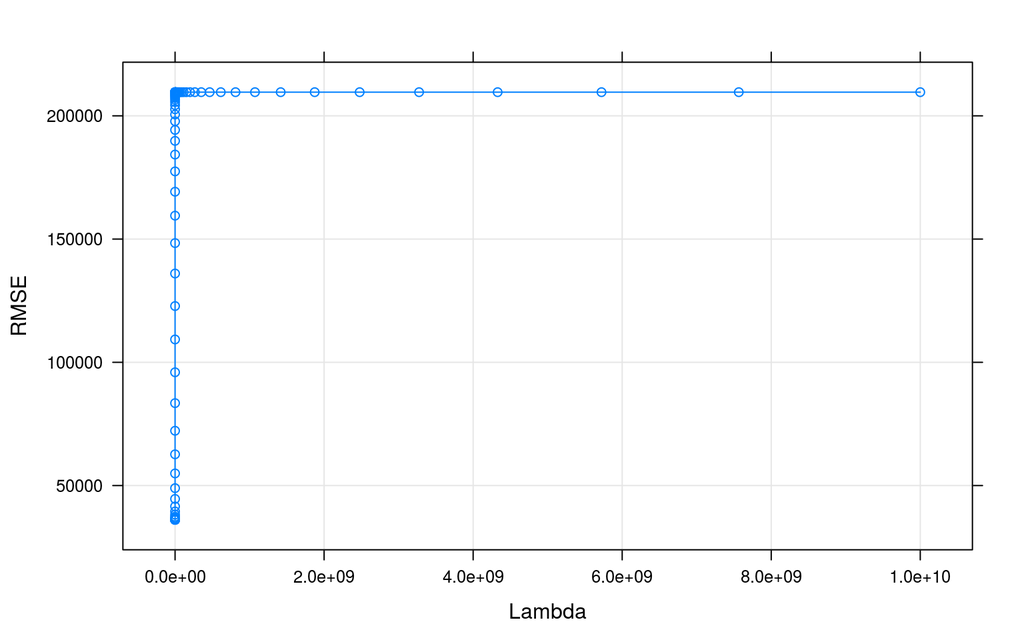

```r
plot(model.ridge, xlab = "Lambda", ylab = "RMSE")
```

## Modelo de Regressão Lasso

O método Lasso é uma recente alternativa ao método Ridge. A desvantagem da Ridge é que ela utiliza todas as variáveis. Nele, embora coeficientes tendam a se aproximar de 0, todos são utilizados. No método Lasso, alguns coeficientes são forçados a redução à exatamente 0, e isso significa que podemos descartar algumas variáveis. Essa é a grande vantagem do método Lasso em detrimento do método Ridge.

```r
require(caret)

# Tunando o hiperparâmetro lambda para penalização dos coeficientes
lambda_grid = expand.grid(fraction = seq(.001, .1, length = 100))

model.lasso = train(votos ~ .,
                    data = train_data,
                    method = "lasso",
                    trControl = fit_control,
                    tuneGrid = lambda_grid,
                    tuneLength = 100,
                    metric="RMSE",
                    preProcess = c("scale", "center"),
                    na.action = na.omit)
```

### Avaliando treino

```r
model.lasso
```

```
## The lasso
##
## 7476 samples
##   20 predictors
##
## Pre-processing: scaled (20), centered (20)
## Resampling: Cross-Validated (10 fold)
## Summary of sample sizes: 6728, 6728, 6728, 6728, 6730, 6728, ...
## Resampling results across tuning parameters:
##
##   fraction  RMSE      Rsquared   MAE
##   0.001     38346.59  0.4080247  20560.67
##   0.002     36218.04  0.4220127  19637.25
##   0.003     36014.17  0.4247924  19912.59
##   0.004     36098.69  0.4223266  20009.73
##   0.005     36231.37  0.4192230  20021.99
##   0.006     36384.57  0.4159841  20033.51
##   0.007     36555.93  0.4127360  20044.83
##   0.008     36742.18  0.4096051  20055.36
##   0.009     36941.08  0.4066541  20065.74
##   0.010     37150.69  0.4039181  20076.12
##   0.011     37369.32  0.4014118  20086.49
##   0.012     37595.60  0.3991351  20096.87
##   0.013     37828.36  0.3970785  20107.24
##   0.014     38066.65  0.3952270  20117.62
##   0.015     38309.67  0.3935635  20128.00
##   0.016     38556.76  0.3920699  20138.37
##   0.017     38807.36  0.3907288  20148.75
##   0.018     39061.01  0.3895235  20159.13
##   0.019     39317.34  0.3884392  20169.50
##   0.020     39575.99  0.3874619  20179.88
##   0.021     39836.71  0.3865797  20190.25
##   0.022     40099.24  0.3857817  20200.63
##   0.023     40363.39  0.3850584  20211.01
##   0.024     40628.98  0.3844014  20221.38
##   0.025     40895.86  0.3838034  20231.76
##   0.026     41163.89  0.3832578  20242.14
##   0.027     41432.96  0.3827591  20252.51
##   0.028     41702.97  0.3823023  20262.89
##   0.029     41973.83  0.3818829  20273.26
```

[output cut: 59 more lines]

```
##   0.089     58727.39  0.3757623  20895.83
##   0.090     59009.34  0.3757420  20906.21
##   0.091     59291.32  0.3757222  20916.59
##   0.092     59573.32  0.3757031  20926.96
##   0.093     59855.36  0.3756845  20937.34
##   0.094     60137.42  0.3756664  20947.72
##   0.095     60419.50  0.3756489  20958.09
##   0.096     60701.62  0.3756318  20968.47
##   0.097     60983.75  0.3756152  20978.84
##   0.098     61265.91  0.3755991  20989.22
##   0.099     61548.09  0.3755834  20999.60
##   0.100     61830.30  0.3755682  21009.97
##
## RMSE was used to select the optimal model using the smallest value.
## The final value used for the model was fraction = 0.003.
```

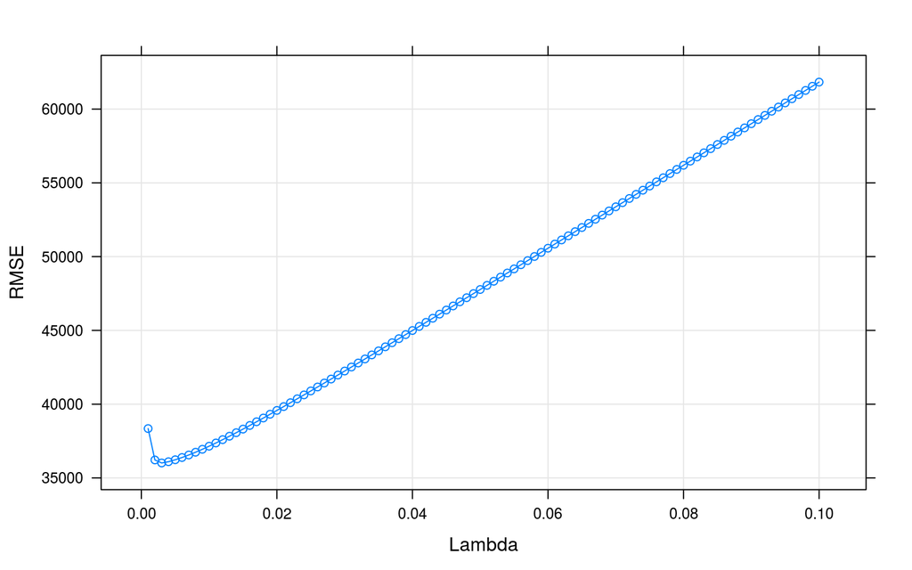

```r
plot(model.lasso, xlab = "Lambda", ylab = "RMSE")
```

## Modelo KNN

```r
n_neighbors_grid = expand.grid(k = seq(1, 100, length=100))

model.knn = train(votos ~ .,
        data = train_data,
        method = "knn",
        trControl = fit_control,
        tuneGrid = n_neighbors_grid,
        tuneLength = 100,
        preProcess = c('scale', 'center'),
        na.action = na.omit)
```

### Avaliando treino

```r
model.knn
```

```
## k-Nearest Neighbors
##
## 7476 samples
##   20 predictors
##
## Pre-processing: scaled (20), centered (20)
## Resampling: Cross-Validated (10 fold)
## Summary of sample sizes: 6729, 6728, 6728, 6728, 6728, 6728, ...
## Resampling results across tuning parameters:
##
##   k    RMSE      Rsquared   MAE
##     1  43596.14  0.3446189  16258.82
##     2  37196.55  0.4382635  14115.36
##     3  35426.36  0.4691618  13493.44
##     4  34230.46  0.4935022  13099.84
```

[output cut: 99 more lines]

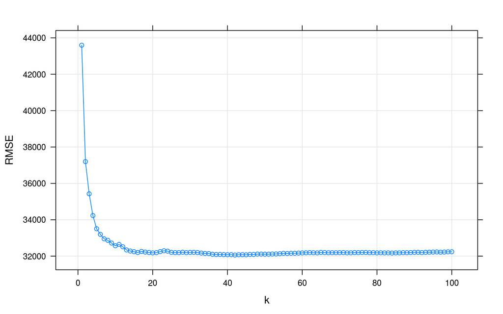

```r
plot(model.knn, xlab = "k", ylab = "RMSE")
```

# Comparando modelos

Portanto o modelo KNN (considerando 42 vizinhos) obteve o melhor resultado! :)

# Quais as variáveis mais importantes segundo o modelo de regressão Ridge e Lasso?

Por importância de uma feature, podemos entender como a dificuldade do método em diminuir o peso ou desconsiderar a feature, sendo um valor variável entre 0 e 100, e considerando features com valores maiores como mais importantes.

```r
plot_var_imp = function(model) {
  require(ggplot2)
  return(ggplot(varImp(model)) +
           geom_bar(stat="identity", fill="#AD1457", colour="#880E4F") +
           labs(title="Importância de variáveis (Lasso)", y="Importância", x="Variável"))
}
```

## Modelo Ridge

[figure not shown]

```r
plot_var_imp(model.ridge)
```

Como pode ser visto no gráfico, o modelo Ridge considerou as seguintes três variáveis como as mais importantes:

- total_despesa
- total_receita
- recursos_de_pessoas_jurídicas

Por outro lado, as seguintes features tiveram pouca importância para o modelo: - grau - ocupacao - partido - sexo - uf - ano

## Lasso

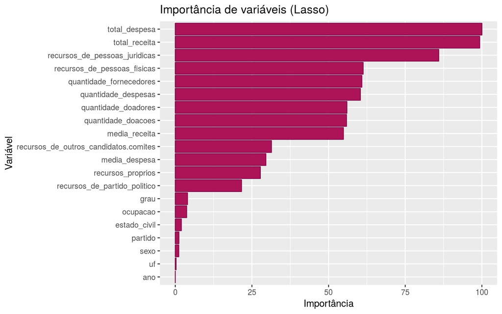

```r
plot_var_imp(model.lasso)
```

O modelo Lasso obteve o mesmo resultado do modelo Ridge. No entando, o que é importanto de observar nesse modelo é que a variável *ano* foi descartada.

# Re-treine o melhor modelo (sem validação cruzada)

O melhor modelo encontrado foi o do método KNN, para um valor k de vizinho entre 15 e 100.

```r
best.model = train(votos ~ .,
                   data = train_data,
                   method = "knn",
                   na.action = na.omit,
                   tuneGrid = data.frame(k = 15),
                   preProcess = c('scale', 'center'))
```

```r
best.model
```

```
## k-Nearest Neighbors
##
## 7476 samples
##   20 predictors
##
## Pre-processing: scaled (20), centered (20)
## Resampling: Bootstrapped (25 reps)
## Summary of sample sizes: 7476, 7476, 7476, 7476, 7476, 7476, ...
## Resampling results:
##
##   RMSE      Rsquared   MAE
##   34514.25  0.4898974  12578.31
##
## Tuning parameter 'k' was held constant at a value of 15
```

# Prevendo votos…

Vamos usar nosso último modelo para prever quantidade de votos! :)

```r
predictions = predict(best.model, test_data)
submission = data.frame(ID = as.character(ID), votos = predictions)
write.csv(submission, "submission.csv", row.names = F)

submission %>%
  glimpse()
```

```
## Observations: 4,598
## Variables: 2
## $ ID    <fct> 10000000135, 10000000142, 10000000158, 10000000161, 1000...
## $ votos <dbl> 136449.1, 126671.4, 142032.9, 156745.8, 140915.9, 111476...
```

Ítalo Batista

7 de outubro de 2018